# WNV Mosquito Test Results Analytics - Team 4

## Setup

Load the libraries here  
setting “message=False” will exclude warning messages for this chunk from your report (recommended for aesthetic)

```r
library(rpart)      #need it for recursive partitioning and decision tree
library(rpart.plot) #need it to plot rpart binary tree
library(caret)      #need it for classification and regression training
library(ggplot2)    #need it for creating fancy chart
library(forecast)   #For time series chart
library(tidyverse)  #for using fundtion of %>%
library(MASS)       #for stepAIC logistic regression model
library(gains)      #for gain chart
```

## Loading the data

Load the CSV file into R. To simplify the process, save this notebook file and the data in the SAME FOLDER before running this line.

```r
WNV <- read.csv("WNV_R.csv", header = TRUE)
```

## Data exploration

Find out the statistical summary of WNV dataset.

```r
summary(WNV)
```

```
##   SEASON.YEAR        WEEK          TEST.ID
##  Min.   :2007   Min.   :20.00   Min.   :20000
##  1st Qu.:2009   1st Qu.:28.00   1st Qu.:27689
##  Median :2012   Median :31.00   Median :35088
##  Mean   :2012   Mean   :31.04   Mean   :35097
##  3rd Qu.:2016   3rd Qu.:35.00   3rd Qu.:42554
##  Max.   :2019   Max.   :40.00   Max.   :49913
##
##                       BLOCK            TRAP          TRAP_TYPE
##  100XX W OHARE AIRPORT   : 2946   T115   :  786   CDC     : 1256
##  127XX S DOTY AVE        :  786   T002   :  591   GRAVID  :27843
##  101XX S STONY ISLAND AVE:  625   T138   :  553   OVI     :    1
##  41XX N OAK PARK AVE     :  595   T114   :  502   SENTINEL:  273
##  52XX S KOLMAR AVE       :  512   T151   :  482
##  70XX W ARMITAGE AVE     :  482   T008   :  474
##  (Other)                 :23427   (Other):25985
##         TEST.DATE     NUMBER.OF.MOSQUITOES      RESULT
##  8/1/07 2:08 :  551   Min.   : 1.00        negative:26890
##  8/15/07 0:08:  276   1st Qu.: 2.00        positive: 2483
##  8/3/12 0:08 :  245   Median : 5.00
##  8/21/14 0:08:  238   Mean   :12.36
##  7/27/12 0:07:  237   3rd Qu.:16.00
##  8/14/14 0:08:  227   Max.   :77.00
##  (Other)     :27599
##                    SPECIES         LATITUDE       LONGITUDE
##  CULEX PIPIENS/RESTUANS:13282   Min.   :41.06   Min.   :-88.46
##  CULEX RESTUANS        :10026   1st Qu.:41.70   1st Qu.:-87.78
##  CULEX PIPIENS         : 4863   Median :41.80   Median :-87.70
##  CULEX TERRITANS       :  902   Mean   :41.78   Mean   :-87.77
##  CULEX SALINARIUS      :  217   3rd Qu.:41.92   3rd Qu.:-87.64
##  CULEX TARSALIS        :   46   Max.   :42.02   Max.   :-87.53
##  (Other)               :   37
##                                      LOCATION         Wards
##  (41.456854,-88.460836)                  : 2946   Min.   : 1.00
##  (41.66238672759086, -87.59017972751752) :  786   1st Qu.:19.00
##  (41.956298856118664, -87.79751744482932):  591   Median :29.00
##  (41.71054240215372, -87.58455893336821) :  553   Mean   :28.78
##  (41.79821072626856, -87.73692496319906) :  502   3rd Qu.:42.00
##  (41.91613471854847, -87.80109280863755) :  482   Max.   :50.00
##  (Other)                                 :23513   NA's   :4410
##  Census.Tracts     Zip.Codes     Community.Areas
##  Min.   :  6.0   Min.   : 4299   Min.   : 4.00
##  1st Qu.:176.0   1st Qu.:21202   1st Qu.:24.00
##  Median :391.0   Median :22212   Median :48.00
##  Mean   :406.6   Mean   :25988   Mean   :42.24
##  3rd Qu.:637.0   3rd Qu.:22532   3rd Qu.:61.00
##  Max.   :787.0   Max.   :60666   Max.   :77.00
##  NA's   :4410                    NA's   :4410
##  Historical.Wards.2003.2015
##  Min.   : 1.00
##  1st Qu.:20.00
##  Median :34.00
##  Mean   :31.72
##  3rd Qu.:45.00
##  Max.   :53.00
##  NA's   :4410
```

Note that a total of 4410 NA records that associated with 4 variables  
Two solutions:  
1. Replace missing values. Latitude, longitude and zip code can be identified from the address field  
2. Omission. The remaining 4 variables will be removed in the following processes. Variables that are still missing: Wards, Census Tracts, Community Areas & Historical Wards 2003-2015.  
So the team decide to remove 4410 missing record rows since the team cannot find more information to fill these blanks.

```r
WNV<- WNV[!is.na(WNV$Wards),]
```

## Correlation - Dimension Reduction

Form a correlation table to reduce redundancy and multicollinearity

```r
wnvnum<-WNV[,sapply(WNV,is.numeric)] #Only numerical number
round(cor(wnvnum),2)  #Display correlation table with 2 decimal number
```

```
##                            SEASON.YEAR  WEEK TEST.ID NUMBER.OF.MOSQUITOES
## SEASON.YEAR                       1.00 -0.01    0.99                -0.03
## WEEK                             -0.01  1.00    0.07                -0.02
## TEST.ID                           0.99  0.07    1.00                -0.04
## NUMBER.OF.MOSQUITOES             -0.03 -0.02   -0.04                 1.00
## LATITUDE                          0.08 -0.01    0.08                -0.03
## LONGITUDE                        -0.06  0.02   -0.06                -0.04
## Wards                            -0.08  0.01   -0.09                 0.06
## Census.Tracts                     0.02 -0.02    0.02                -0.01
## Zip.Codes                         0.00  0.00    0.00                -0.02
## Community.Areas                   0.02  0.00    0.02                -0.02
## Historical.Wards.2003.2015        0.00  0.00    0.00                 0.11
##                            LATITUDE LONGITUDE Wards Census.Tracts
## SEASON.YEAR                    0.08     -0.06 -0.08          0.02
## WEEK                          -0.01      0.02  0.01         -0.02
## TEST.ID                        0.08     -0.06 -0.09          0.02
## NUMBER.OF.MOSQUITOES          -0.03     -0.04  0.06         -0.01
## LATITUDE                       1.00     -0.70 -0.19          0.19
## LONGITUDE                     -0.70      1.00  0.37         -0.08
## Wards                         -0.19      0.37  1.00         -0.04
## Census.Tracts                  0.19     -0.08 -0.04          1.00
## Zip.Codes                     -0.04      0.17  0.09         -0.12
## Community.Areas               -0.56      0.30 -0.07         -0.15
## Historical.Wards.2003.2015    -0.24      0.22  0.16          0.10
##                            Zip.Codes Community.Areas
## SEASON.YEAR                     0.00            0.02
## WEEK                            0.00            0.00
## TEST.ID                         0.00            0.02
## NUMBER.OF.MOSQUITOES           -0.02           -0.02
## LATITUDE                       -0.04           -0.56
## LONGITUDE                       0.17            0.30
## Wards                           0.09           -0.07
## Census.Tracts                  -0.12           -0.15
## Zip.Codes                       1.00           -0.15
## Community.Areas                -0.15            1.00
## Historical.Wards.2003.2015      0.05            0.10
##                            Historical.Wards.2003.2015
## SEASON.YEAR                                      0.00
## WEEK                                             0.00
## TEST.ID                                          0.00
## NUMBER.OF.MOSQUITOES                             0.11
## LATITUDE                                        -0.24
## LONGITUDE                                        0.22
## Wards                                            0.16
## Census.Tracts                                    0.10
## Zip.Codes                                        0.05
## Community.Areas                                  0.10
## Historical.Wards.2003.2015                       1.00
```

## Data Visualization

Historgram of the number of mosquitoes

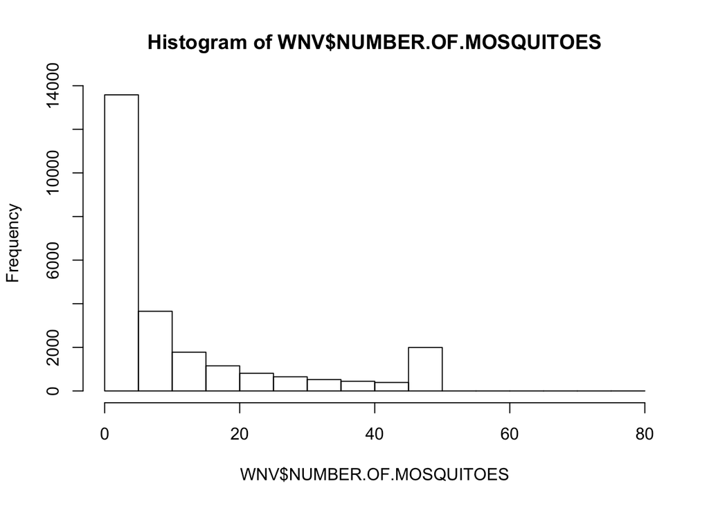

```r
hist(WNV$NUMBER.OF.MOSQUITOES)
```

Plot of each test location over longitude and latitude.

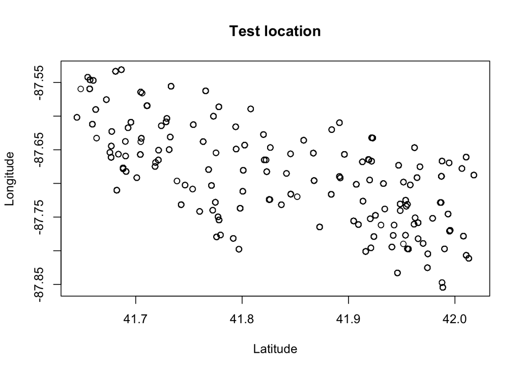

```r
plot(WNV$LATITUDE,WNV$LONGITUDE, main = "Test location",xlab = "Latitude",ylab = "Longitude")
```

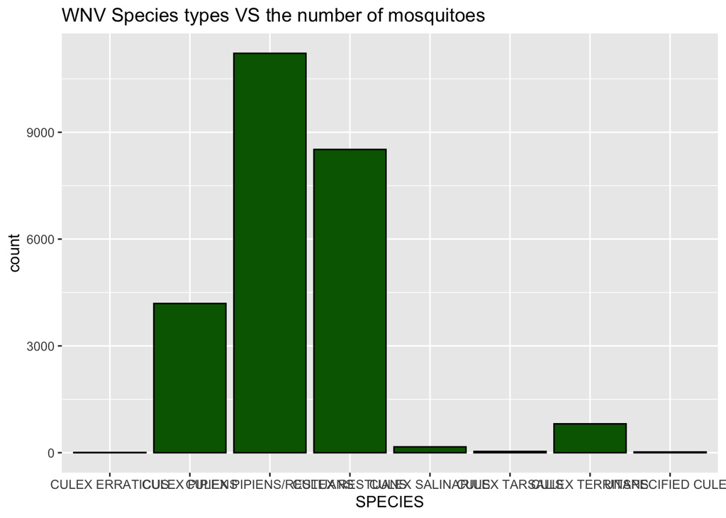

```r
s <- ggplot(data = WNV)
s + geom_bar(aes(x=SPECIES), fill="DarkGreen", colour="Black") + ggtitle("WNV Species types VS the number of mosquitoes")
```

Histogram of mosquitoes by different types

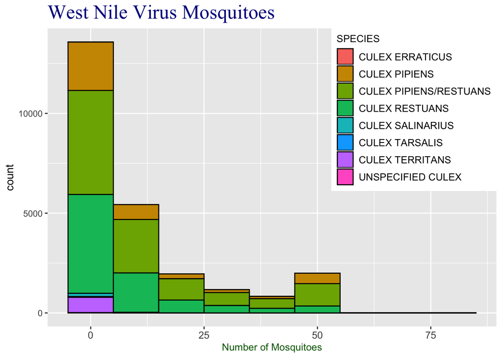

```r
s + geom_histogram(binwidth = 10, aes(x=NUMBER.OF.MOSQUITOES,
                                    fill=SPECIES), colour="Black") + xlab("Number of Mosquitoes") +
  ggtitle("West Nile Virus Mosquitoes") +
  theme(axis.title.x = element_text(colour = "DarkGreen", size = 10),
        axis.text.x = element_text(size = 10),
        legend.title = element_text(size = 10),
        legend.text = element_text(size  = 10),
        legend.position = c(1,1),
        legend.justification = c(1,1),
        plot.title = element_text(colour = "DarkBlue", size = 20, family = "Times New Roman"))
```

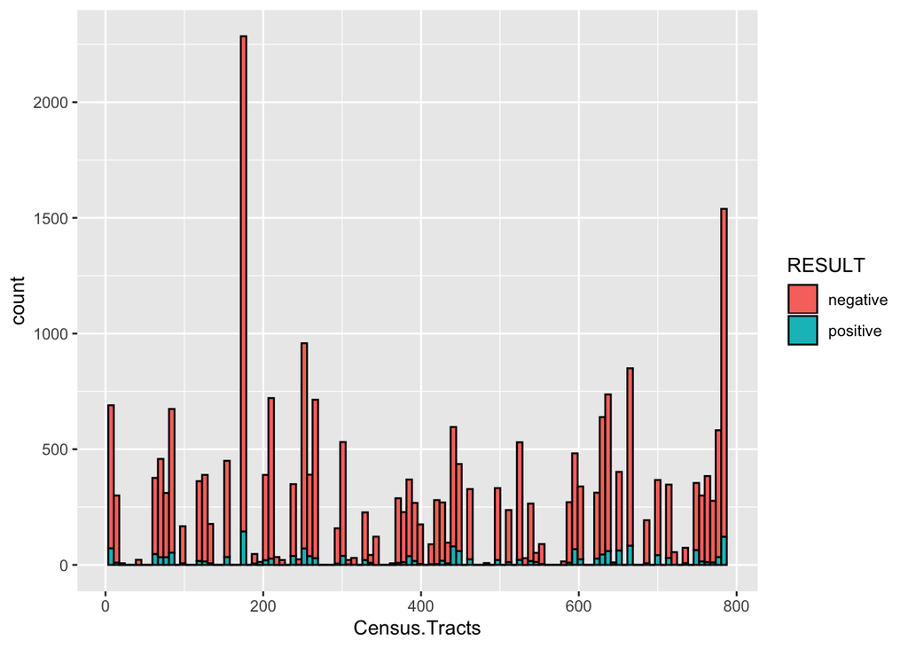

```r
s + geom_histogram(binwidth = 7, aes(x=Census.Tracts,fill=RESULT), colour="Black")
```

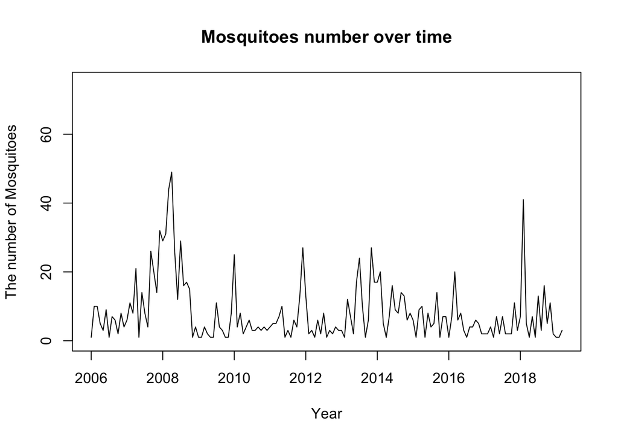

```r
WNV.ts <- ts(WNV$NUMBER.OF.MOSQUITOES, start = c(2006, 1), end = c(2019, 3), freq = 12)
plot(WNV.ts, main = "Mosquitoes number over time",xlab = "Year", ylab = "The number of Mosquitoes", ylim = c(0, 75))
```

## Partitioning datasets

Convert RESULT from positive,negaetive into 1,0 in order to get better result in lift chart.

```r
WNV$isPos <- 1 * (WNV$RESULT == "positive")
```

The variables the team decide to remove:  
1. TEST.ID - unique each row(0.99 cor with year), explained before too  
2. BLOCK - specific address  
3. TRAP - trap ID  
4. Test.Date - test once a week which has already been represented in WEEK variable  
5. Location - combined Longitude and Latitude  
6. RESULT - since we already added isPos instead of RESULT as response variable

```r
wnv<- WNV[!is.na(WNV$Wards),-c(3,4,5,7,9,13)]
```

Observation Sampling:  
60% of the total record 14977 are assigned to be training data  
40% of the total record 9986 are assigned to be validation data

```r
set.seed(1)
train.index <- sample(c(1:dim(wnv)[1]), dim(wnv)[1]*0.6)
train <- wnv[train.index, ]
valid<- wnv[-train.index, ]
```

## Building Logistic Models and Model Selection

Model m1 is the full model fitting all the predictors, used for stepAIC function getting best model.

```r
options(digits = 4)
options(scipen=999) ##Show the result without scientific notation and with 4 digits
m1=glm(isPos~.,family="binomial", data=train)
summary(m1)
```

```
##
## Call:
## glm(formula = isPos ~ ., family = "binomial", data = train)
##
## Deviance Residuals:
##    Min      1Q  Median      3Q     Max
## -1.717  -0.378  -0.263  -0.176   3.067
##
## Coefficients:
##                                    Estimate    Std. Error z value
## (Intercept)                   -488.17757466 1706.51981700   -0.29
## SEASON.YEAR                      0.09384032    0.01020287    9.20
## WEEK                             0.11673584    0.00887679   13.15
## TRAP_TYPEGRAVID                  1.14224990    0.21268056    5.37
## TRAP_TYPEOVI                   -11.60134922 3956.18033631    0.00
## TRAP_TYPESENTINEL                0.86615101    0.32486300    2.67
## NUMBER.OF.MOSQUITOES             0.06226098    0.00197604   31.51
## SPECIESCULEX PIPIENS            15.18922770 1705.66581075    0.01
## SPECIESCULEX PIPIENS/RESTUANS   14.93736375 1705.66580943    0.01
## SPECIESCULEX RESTUANS           14.83332898 1705.66581007    0.01
## SPECIESCULEX SALINARIUS         14.18920137 1705.66610664    0.01
## SPECIESCULEX TARSALIS            0.64036281 1915.74258637    0.00
## SPECIESCULEX TERRITANS           0.72879991 1714.27399039    0.00
## SPECIESUNSPECIFIED CULEX         0.69106742 2018.11895530    0.00
## LATITUDE                        -0.17390696    0.51868606   -0.34
## LONGITUDE                       -3.22641474    0.70458753   -4.58
## Wards                            0.00188947    0.00266886    0.71
## Census.Tracts                    0.00029916    0.00014893    2.01
## Zip.Codes                        0.00000889    0.00000626    1.42
## Community.Areas                  0.00184154    0.00188895    0.97
## Historical.Wards.2003.2015      -0.00429263    0.00272770   -1.57
##                                           Pr(>|z|)
## (Intercept)                                 0.7748
## SEASON.YEAR                   < 0.0000000000000002 ***
## WEEK                          < 0.0000000000000002 ***
## TRAP_TYPEGRAVID                        0.000000078 ***
## TRAP_TYPEOVI                                0.9977
## TRAP_TYPESENTINEL                           0.0077 **
## NUMBER.OF.MOSQUITOES          < 0.0000000000000002 ***
## SPECIESCULEX PIPIENS                        0.9929
```

[output cut: 8 more lines]

```
## Wards                                       0.4790
## Census.Tracts                               0.0446 *
## Zip.Codes                                   0.1555
## Community.Areas                             0.3296
## Historical.Wards.2003.2015                  0.1156
## ---
## Signif. codes:  0 '***' 0.001 '**' 0.01 '*' 0.05 '.' 0.1 ' ' 1
##
## (Dispersion parameter for binomial family taken to be 1)
##
##     Null deviance: 8088.0  on 14976  degrees of freedom
## Residual deviance: 6530.4  on 14956  degrees of freedom
## AIC: 6572
##
## Number of Fisher Scoring iterations: 16
```

lmodel is the best model selected by the stepwise function according to best AIC.

```r
lmodel <- glm(isPos ~., data = train, family = "binomial") %>% stepAIC(trace = FALSE)
summary(lmodel)
```

```
##
## Call:
## glm(formula = isPos ~ SEASON.YEAR + WEEK + TRAP_TYPE + NUMBER.OF.MOSQUITOES +
##     SPECIES + LONGITUDE + Census.Tracts + Historical.Wards.2003.2015,
##     family = "binomial", data = train)
##
## Deviance Residuals:
##    Min      1Q  Median      3Q     Max
## -1.665  -0.377  -0.263  -0.176   3.050
##
## Coefficients:
##                                  Estimate  Std. Error z value
## (Intercept)                   -449.762222 1703.309953   -0.26
## SEASON.YEAR                      0.093828    0.010185    9.21
## WEEK                             0.116800    0.008868   13.17
## TRAP_TYPEGRAVID                  1.129620    0.211255    5.35
## TRAP_TYPEOVI                   -11.666297 3956.180335    0.00
## TRAP_TYPESENTINEL                0.855640    0.322796    2.65
## NUMBER.OF.MOSQUITOES             0.062261    0.001974   31.54
## SPECIESCULEX PIPIENS            15.226293 1702.731313    0.01
## SPECIESCULEX PIPIENS/RESTUANS   14.969117 1702.731312    0.01
## SPECIESCULEX RESTUANS           14.865277 1702.731313    0.01
## SPECIESCULEX SALINARIUS         14.211603 1702.731610    0.01
## SPECIESCULEX TARSALIS            0.662587 1913.260631    0.00
## SPECIESCULEX TERRITANS           0.759367 1711.360167    0.00
## SPECIESUNSPECIFIED CULEX         0.737018 2016.125247    0.00
## LONGITUDE                       -2.709131    0.453479   -5.97
## Census.Tracts                    0.000228    0.000141    1.62
## Historical.Wards.2003.2015      -0.003991    0.002693   -1.48
##                                           Pr(>|z|)
## (Intercept)                                  0.792
## SEASON.YEAR                   < 0.0000000000000002 ***
## WEEK                          < 0.0000000000000002 ***
## TRAP_TYPEGRAVID                       0.0000000893 ***
## TRAP_TYPEOVI                                 0.998
## TRAP_TYPESENTINEL                            0.008 **
## NUMBER.OF.MOSQUITOES          < 0.0000000000000002 ***
## SPECIESCULEX PIPIENS                         0.993
## SPECIESCULEX PIPIENS/RESTUANS                0.993
## SPECIESCULEX RESTUANS                        0.993
## SPECIESCULEX SALINARIUS                      0.993
## SPECIESCULEX TARSALIS                        1.000
## SPECIESCULEX TERRITANS                       1.000
## SPECIESUNSPECIFIED CULEX                     1.000
## LONGITUDE                             0.0000000023 ***
## Census.Tracts                                0.105
## Historical.Wards.2003.2015                   0.138
## ---
## Signif. codes:  0 '***' 0.001 '**' 0.01 '*' 0.05 '.' 0.1 ' ' 1
##
## (Dispersion parameter for binomial family taken to be 1)
##
##     Null deviance: 8088.0  on 14976  degrees of freedom
## Residual deviance: 6533.7  on 14960  degrees of freedom
## AIC: 6568
##
## Number of Fisher Scoring iterations: 16
```

```r
m2=glm(isPos~SEASON.YEAR+WEEK+TRAP_TYPE+NUMBER.OF.MOSQUITOES+LONGITUDE+SPECIES,family="binomial",data=train)
summary(m2)
```

```
##
## Call:
## glm(formula = isPos ~ SEASON.YEAR + WEEK + TRAP_TYPE + NUMBER.OF.MOSQUITOES +
##     LONGITUDE + SPECIES, family = "binomial", data = train)
##
## Deviance Residuals:
##    Min      1Q  Median      3Q     Max
## -1.717  -0.378  -0.262  -0.176   3.083
##
## Coefficients:
##                                 Estimate Std. Error z value
## (Intercept)                   -462.40667 1712.84062   -0.27
## SEASON.YEAR                      0.09326    0.01017    9.17
## WEEK                             0.11683    0.00886   13.19
## TRAP_TYPEGRAVID                  1.22160    0.20661    5.91
## TRAP_TYPEOVI                   -11.74883 3956.18034    0.00
## TRAP_TYPESENTINEL                0.92993    0.32039    2.90
## NUMBER.OF.MOSQUITOES             0.06227    0.00197   31.61
## LONGITUDE                       -2.86512    0.44316   -6.47
## SPECIESCULEX PIPIENS            15.21744 1712.28332    0.01
## SPECIESCULEX PIPIENS/RESTUANS   14.96385 1712.28331    0.01
## SPECIESCULEX RESTUANS           14.86185 1712.28332    0.01
## SPECIESCULEX SALINARIUS         14.18809 1712.28361    0.01
## SPECIESCULEX TARSALIS            0.62728 1921.06375    0.00
## SPECIESCULEX TERRITANS           0.74718 1720.87015    0.00
## SPECIESUNSPECIFIED CULEX         0.70603 2023.12965    0.00
##                                           Pr(>|z|)
## (Intercept)                                 0.7872
## SEASON.YEAR                   < 0.0000000000000002 ***
## WEEK                          < 0.0000000000000002 ***
## TRAP_TYPEGRAVID                       0.0000000034 ***
## TRAP_TYPEOVI                                0.9976
## TRAP_TYPESENTINEL                           0.0037 **
## NUMBER.OF.MOSQUITOES          < 0.0000000000000002 ***
## LONGITUDE                             0.0000000001 ***
## SPECIESCULEX PIPIENS                        0.9929
## SPECIESCULEX PIPIENS/RESTUANS               0.9930
## SPECIESCULEX RESTUANS                       0.9931
## SPECIESCULEX SALINARIUS                     0.9934
## SPECIESCULEX TARSALIS                       0.9997
## SPECIESCULEX TERRITANS                      0.9997
## SPECIESUNSPECIFIED CULEX                    0.9997
## ---
## Signif. codes:  0 '***' 0.001 '**' 0.01 '*' 0.05 '.' 0.1 ' ' 1
##
## (Dispersion parameter for binomial family taken to be 1)
##
##     Null deviance: 8088.0  on 14976  degrees of freedom
## Residual deviance: 6537.9  on 14962  degrees of freedom
## AIC: 6568
##
## Number of Fisher Scoring iterations: 16
```

Since Species variable is still not significant in Model m2, so Species is removed in Model m3.

```r
m3=glm(isPos~SEASON.YEAR+WEEK+TRAP_TYPE+NUMBER.OF.MOSQUITOES+LONGITUDE,family="binomial",data=train)
summary(m3)
```

```
##
## Call:
## glm(formula = isPos ~ SEASON.YEAR + WEEK + TRAP_TYPE + NUMBER.OF.MOSQUITOES +
##     LONGITUDE, family = "binomial", data = train)
##
## Deviance Residuals:
##    Min      1Q  Median      3Q     Max
## -1.719  -0.373  -0.262  -0.185   3.120
##
## Coefficients:
##                        Estimate Std. Error z value             Pr(>|z|)
## (Intercept)          -434.20449   43.00313  -10.10 < 0.0000000000000002
## SEASON.YEAR             0.08583    0.00973    8.82 < 0.0000000000000002
## WEEK                    0.12334    0.00848   14.55 < 0.0000000000000002
## TRAP_TYPEGRAVID         1.07558    0.19709    5.46       0.000000048325
## TRAP_TYPEOVI           -5.58721  196.96782   -0.03                0.977
## TRAP_TYPESENTINEL       0.75919    0.31517    2.41                0.016
## NUMBER.OF.MOSQUITOES    0.06338    0.00191   33.17 < 0.0000000000000002
## LONGITUDE              -2.88354    0.44240   -6.52       0.000000000071
##
## (Intercept)          ***
## SEASON.YEAR          ***
## WEEK                 ***
## TRAP_TYPEGRAVID      ***
## TRAP_TYPEOVI
## TRAP_TYPESENTINEL    *
## NUMBER.OF.MOSQUITOES ***
## LONGITUDE            ***
## ---
## Signif. codes:  0 '***' 0.001 '**' 0.01 '*' 0.05 '.' 0.1 ' ' 1
##
## (Dispersion parameter for binomial family taken to be 1)
##
##     Null deviance: 8088.0  on 14976  degrees of freedom
## Residual deviance: 6587.5  on 14969  degrees of freedom
## AIC: 6603
##
## Number of Fisher Scoring iterations: 10
```

Computing confusion matrix for lmodel

```r
pred <- predict(lmodel, valid)
confusionMatrix(as.factor(ifelse(pred > 0.5, 1, 0)), as.factor(valid$isPos))
```

```
## Confusion Matrix and Statistics
##
##           Reference
## Prediction    0    1
##          0 9241  715
##          1   16   14
##
##                Accuracy : 0.927
##                  95% CI : (0.922, 0.932)
##     No Information Rate : 0.927
##     P-Value [Acc > NIR] : 0.54
##
##                   Kappa : 0.031
##
##  Mcnemar's Test P-Value : <0.0000000000000002
##
##             Sensitivity : 0.9983
##             Specificity : 0.0192
##          Pos Pred Value : 0.9282
##          Neg Pred Value : 0.4667
##              Prevalence : 0.9270
##          Detection Rate : 0.9254
##    Detection Prevalence : 0.9970
##       Balanced Accuracy : 0.5087
##
##        'Positive' Class : 0
##
```

Computing confusion matrix for m2

```r
pred <- predict(m2, valid)
confusionMatrix(as.factor(ifelse(pred > 0.5, 1, 0)), as.factor(valid$isPos))
```

```
## Confusion Matrix and Statistics
##
##           Reference
## Prediction    0    1
##          0 9243  716
##          1   14   13
##
##                Accuracy : 0.927
##                  95% CI : (0.922, 0.932)
##     No Information Rate : 0.927
##     P-Value [Acc > NIR] : 0.525
##
##                   Kappa : 0.029
##
##  Mcnemar's Test P-Value : <0.0000000000000002
##
##             Sensitivity : 0.9985
##             Specificity : 0.0178
##          Pos Pred Value : 0.9281
##          Neg Pred Value : 0.4815
##              Prevalence : 0.9270
##          Detection Rate : 0.9256
##    Detection Prevalence : 0.9973
##       Balanced Accuracy : 0.5082
##
##        'Positive' Class : 0
##
```

Computing confusion matrix for m3

```r
pred <- predict(m3, valid)
confusionMatrix(as.factor(ifelse(pred > 0.5, 1, 0)), as.factor(valid$isPos))
```

```
## Confusion Matrix and Statistics
##
##           Reference
## Prediction    0    1
##          0 9244  716
##          1   13   13
##
##                Accuracy : 0.927
##                  95% CI : (0.922, 0.932)
##     No Information Rate : 0.927
##     P-Value [Acc > NIR] : 0.51
##
##                   Kappa : 0.03
##
##  Mcnemar's Test P-Value : <0.0000000000000002
##
##             Sensitivity : 0.9986
##             Specificity : 0.0178
##          Pos Pred Value : 0.9281
##          Neg Pred Value : 0.5000
##              Prevalence : 0.9270
##          Detection Rate : 0.9257
##    Detection Prevalence : 0.9974
##       Balanced Accuracy : 0.5082
##
##        'Positive' Class : 0
##
```

GLM Model Comparison:

GLM 1 lmodel Stepwise regression has 8 predictors with 6568 AIC, 0.9983 sensitivity, and 0.0192 specification.

GLM 2 m2 has 6 number predictors with 6568 AIC, 0.9985 sensitivity and 0.0178 specification.

GLM 3 m3 has 5 number predictors with 6603 AIC, 0.9986 sensitivity and 0.0178 specification.

## Lift Chart for best model

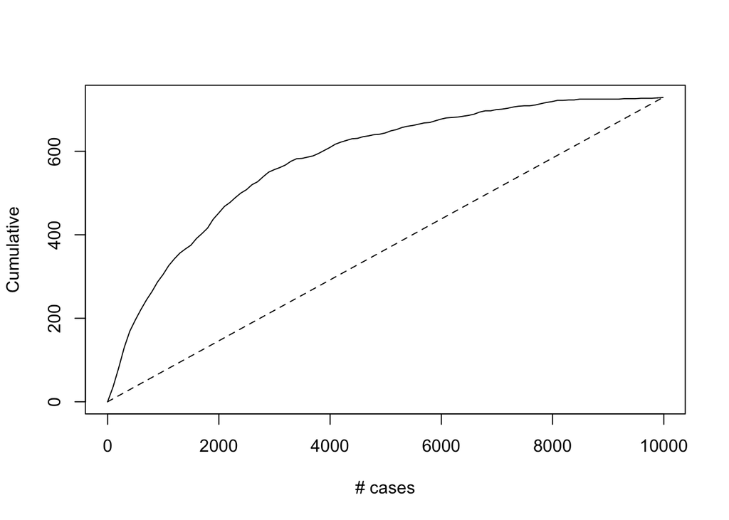

```r
pred <- predict(m3, valid)
gain <- gains(valid$isPos, pred, groups=100)

plot(c(0,gain$cume.pct.of.total*sum(valid$isPos))~
       c(0,gain$cume.obs),
     xlab="# cases", ylab="Cumulative", main="", type="l")
lines(c(0,sum(valid$isPos))~c(0, dim(valid)[1]), lty=2)
```

##Decision Tree

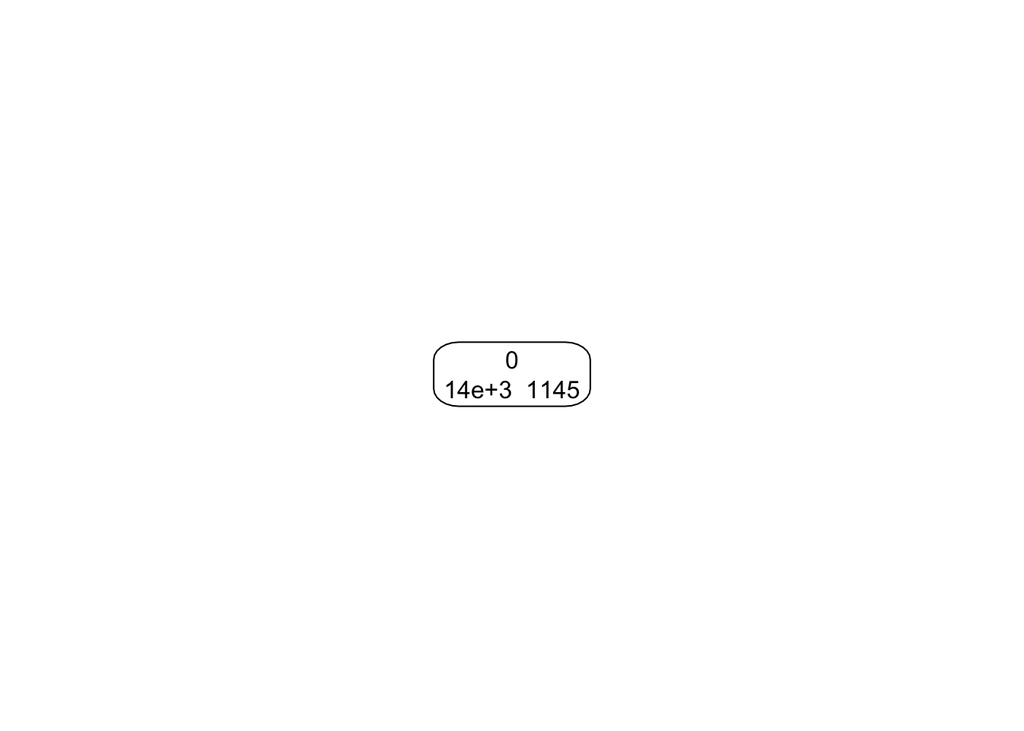

```r
model <-rpart(isPos ~ ., data = train,  method = "class")
# "snipping" off the least important splits - pruning, best prune tree
pruned <- prune(model, cp = model$cptable[which.min(model$cptable[,"xerror"]),"CP"])
prp(pruned, type = 1, extra = 1, split.font = 1, varlen = -10)
```

Decision tree has only one node. We have tested on oversampling the POSITIVE result in the model and the result still remains the same.

## Evaluating Performance on Decision Tree

```r
# use predict() to make predictions for a valid data set.
model.pred <- predict(pruned, valid,type = "class")
# Plot confusion matrix of prediction tree VS actual
confusionMatrix(model.pred, as.factor(valid$isPos))
```

```
## Confusion Matrix and Statistics
##
##           Reference
## Prediction    0    1
##          0 9257  729
##          1    0    0
##
##                Accuracy : 0.927
##                  95% CI : (0.922, 0.932)
##     No Information Rate : 0.927
##     P-Value [Acc > NIR] : 0.51
##
##                   Kappa : 0
##
##  Mcnemar's Test P-Value : <0.0000000000000002
##
##             Sensitivity : 1.000
##             Specificity : 0.000
##          Pos Pred Value : 0.927
##          Neg Pred Value :   NaN
##              Prevalence : 0.927
##          Detection Rate : 0.927
##    Detection Prevalence : 1.000
##       Balanced Accuracy : 0.500
##
##        'Positive' Class : 0
##
```

Decision tree has only one node and no branch of any other rules, thus the evaluation doesn’t make sense.